# Individual Project - Richel (504)

Richel Attafuah

2025-03-20

## **Introduction: Understanding Teenage Birth Rates in the U.S.**

Teenage pregnancy remains a significant public health and social concern in the United States, influencing young mothers’ education, career prospects, and overall well-being. Over the years, various policies, healthcare initiatives, and educational programs have aimed to reduce teenage birth rates. However, disparities persist across states and counties, influenced by socioeconomic factors, access to healthcare, and cultural norms.

This study leverages **county-level teen birth rate data (2003–2020)** to explore: - **How have teenage birth rates changed over time?** - **Which states and counties exhibit the highest and lowest rates?** - **Are there identifiable trends or patterns in birth rates across different regions?**

Using advanced **exploratory data analysis (EDA)** techniques and visually compelling **ggplots** (with colorblind-friendly palettes), this project aims to **uncover key insights, highlight regional disparities, and present findings in an engaging and data-driven manner**.

## **Structure of the Analysis**

The R Markdown will follow this structured approach:

### **Data Cleaning & Preprocessing**

- Checking for missing values and inconsistencies
- Transforming and restructuring data for easy analysis
- Converting categorical variables appropriately

### **Exploratory Data Analysis (EDA)**

- **National Trends**: Evolution of teenage birth rates across the U.S.
- **State & County-Level Trends**: Identifying high and low-rate regions.
- **Distribution Analysis**: Examining the spread of birth rates across different years.
- **Temporal Changes**: How have rates changed from 2003 to 2020?
- **Top & Bottom States**: Identifying consistent trends.

### **Key Findings & Policy Insights**

- Summary of major trends and disparities.
- Recommendations for public health policies and interventions.

### **Loading the Data**

The dataset used in this analysis contains county-level teenage birth rates in the U.S. from 2003 to 2020. It includes variables such as birth rates per 1,000 females aged 15–19, confidence intervals, and geographic identifiers. First, we load the dataset into R, inspect its structure, and perform necessary preprocessing steps to ensure data quality before analysis.

```r
# Read the dataset
df <- read.csv("C:\\Users\\attafuro\\Desktop\\Teenage Pregnancy\\Data.csv")

# View the first few rows
head(df)
```

```
##   Year   State  County State.FIPS.Code County.FIPS.Code Combined.FIPS.Code
## 1 2003 Alabama Autauga               1                1               1001
## 2 2004 Alabama Autauga               1                1               1001
## 3 2005 Alabama Autauga               1                1               1001
## 4 2006 Alabama Autauga               1                1               1001
## 5 2007 Alabama Autauga               1                1               1001
## 6 2008 Alabama Autauga               1                1               1001
##   Birth.Rate Lower.Confidence.Limit Upper.Confidence.Limit
## 1       48.4                   42.2                   55.2
## 2       46.4                   41.7                   51.5
## 3       44.1                   40.3                   48.1
## 4       44.3                   40.8                   48.0
## 5       43.7                   40.3                   47.2
## 6       41.6                   38.4                   45.0
```

```r
# Check structure of the dataset
str(df)
```

```
## 'data.frame':    56466 obs. of  9 variables:
##  $ Year                  : int  2003 2004 2005 2006 2007 2008 2009 2010 2011 2012 ...
##  $ State                 : chr  "Alabama" "Alabama" "Alabama" "Alabama" ...
##  $ County                : chr  "Autauga" "Autauga" "Autauga" "Autauga" ...
##  $ State.FIPS.Code       : int  1 1 1 1 1 1 1 1 1 1 ...
##  $ County.FIPS.Code      : int  1 1 1 1 1 1 1 1 1 1 ...
##  $ Combined.FIPS.Code    : int  1001 1001 1001 1001 1001 1001 1001 1001 1001 1001 ...
##  $ Birth.Rate            : num  48.4 46.4 44.1 44.3 43.7 41.6 38.7 34.7 31.9 30.3 ...
##  $ Lower.Confidence.Limit: num  42.2 41.7 40.3 40.8 40.3 38.4 35.6 31.8 29.2 27.6 ...
##  $ Upper.Confidence.Limit: num  55.2 51.5 48.1 48 47.2 45 41.9 37.7 34.8 33.1 ...
```

```r
# Summary statistics
summary(df)
```

```
##       Year         State              County          State.FIPS.Code
##  Min.   :2003   Length:56466       Length:56466       Min.   : 1.00
##  1st Qu.:2007   Class :character   Class :character   1st Qu.:19.00
##  Median :2012   Mode  :character   Mode  :character   Median :29.00
##  Mean   :2012                                         Mean   :30.32
##  3rd Qu.:2016                                         3rd Qu.:45.00
##  Max.   :2020                                         Max.   :56.00
##  County.FIPS.Code Combined.FIPS.Code   Birth.Rate     Lower.Confidence.Limit
##  Min.   :  1.0    Min.   : 1001      Min.   :  0.70   Min.   :  0.30
##  1st Qu.: 35.0    1st Qu.:19001      1st Qu.: 21.20   1st Qu.: 17.00
##  Median : 79.0    Median :29181      Median : 32.60   Median : 27.70
##  Mean   :103.6    Mean   :30425      Mean   : 35.95   Mean   : 30.83
##  3rd Qu.:133.0    3rd Qu.:45083      3rd Qu.: 47.40   3rd Qu.: 41.80
##  Max.   :840.0    Max.   :56045      Max.   :143.90   Max.   :122.90
##  Upper.Confidence.Limit
##  Min.   :  1.40
##  1st Qu.: 26.00
##  Median : 38.80
##  Mean   : 42.14
##  3rd Qu.: 54.60
##  Max.   :459.40
```

```r
# Check for missing values
missing_values <- colSums(is.na(df))
missing_values
```

```
##                   Year                  State                 County
##                      0                      0                      0
##        State.FIPS.Code       County.FIPS.Code     Combined.FIPS.Code
##                      0                      0                      0
##             Birth.Rate Lower.Confidence.Limit Upper.Confidence.Limit
##                      0                      0                      0
```

```r
# Convert column names to a consistent format
colnames(df) <- colnames(df) %>%
  tolower() %>%
  str_replace_all("\\.", "_")  # Replace periods with underscores for easy referencing

# Convert state and county to factors
df <- df %>%
  mutate(
    state = as.factor(state),
    county = as.factor(county)
  )
# Ensure data types are correctly assigned
str(df)
```

```
## 'data.frame':    56466 obs. of  9 variables:
##  $ year                  : int  2003 2004 2005 2006 2007 2008 2009 2010 2011 2012 ...
##  $ state                 : Factor w/ 51 levels "Alabama","Alaska",..: 1 1 1 1 1 1 1 1 1 1 ...
##  $ county                : Factor w/ 1843 levels "Abbeville","Acadia",..: 82 82 82 82 82 82 82 82 82 82 ...
##  $ state_fips_code       : int  1 1 1 1 1 1 1 1 1 1 ...
##  $ county_fips_code      : int  1 1 1 1 1 1 1 1 1 1 ...
##  $ combined_fips_code    : int  1001 1001 1001 1001 1001 1001 1001 1001 1001 1001 ...
##  $ birth_rate            : num  48.4 46.4 44.1 44.3 43.7 41.6 38.7 34.7 31.9 30.3 ...
##  $ lower_confidence_limit: num  42.2 41.7 40.3 40.8 40.3 38.4 35.6 31.8 29.2 27.6 ...
##  $ upper_confidence_limit: num  55.2 51.5 48.1 48 47.2 45 41.9 37.7 34.8 33.1 ...
```

### **Introduction to Exploratory Data Analysis (EDA)**

In this project, Exploratory Data Analysis (EDA) serves as the foundation for uncovering meaningful patterns and trends in teenage birth rates across U.S. counties from 2003 to 2020. By analyzing the distribution of birth rates, examining changes over time, and comparing variations across states and counties, EDA allows us to understand the scope and dynamics of teenage pregnancy in the United States. This step is essential for identifying disparities, highlighting areas of concern, and informing potential policy discussions—all supported by clean, compelling, and colorblind-friendly visualizations.

```r
# Summary statistics for numerical variables
summary(df %>% select(year, birth_rate, lower_confidence_limit, upper_confidence_limit))
```

```
##       year        birth_rate     lower_confidence_limit upper_confidence_limit
##  Min.   :2003   Min.   :  0.70   Min.   :  0.30         Min.   :  1.40
##  1st Qu.:2007   1st Qu.: 21.20   1st Qu.: 17.00         1st Qu.: 26.00
##  Median :2012   Median : 32.60   Median : 27.70         Median : 38.80
##  Mean   :2012   Mean   : 35.95   Mean   : 30.83         Mean   : 42.14
##  3rd Qu.:2016   3rd Qu.: 47.40   3rd Qu.: 41.80         3rd Qu.: 54.60
##  Max.   :2020   Max.   :143.90   Max.   :122.90         Max.   :459.40
```

The dataset reveals a wide range in teenage birth rates across U.S. counties from 2003 to 2020, with rates ranging from as low as 0.7 to as high as 143.9 births per 1,000 females aged 15–19. The median birth rate stands at 32.6, while the average is slightly higher at 35.95, indicating a slight right skew. Confidence intervals also vary significantly, with the upper bounds reaching up to 459.4 in some counties, suggesting high uncertainty in certain estimates. Overall, the data highlights substantial variation in teenage birth rates and associated uncertainties across different regions and years.

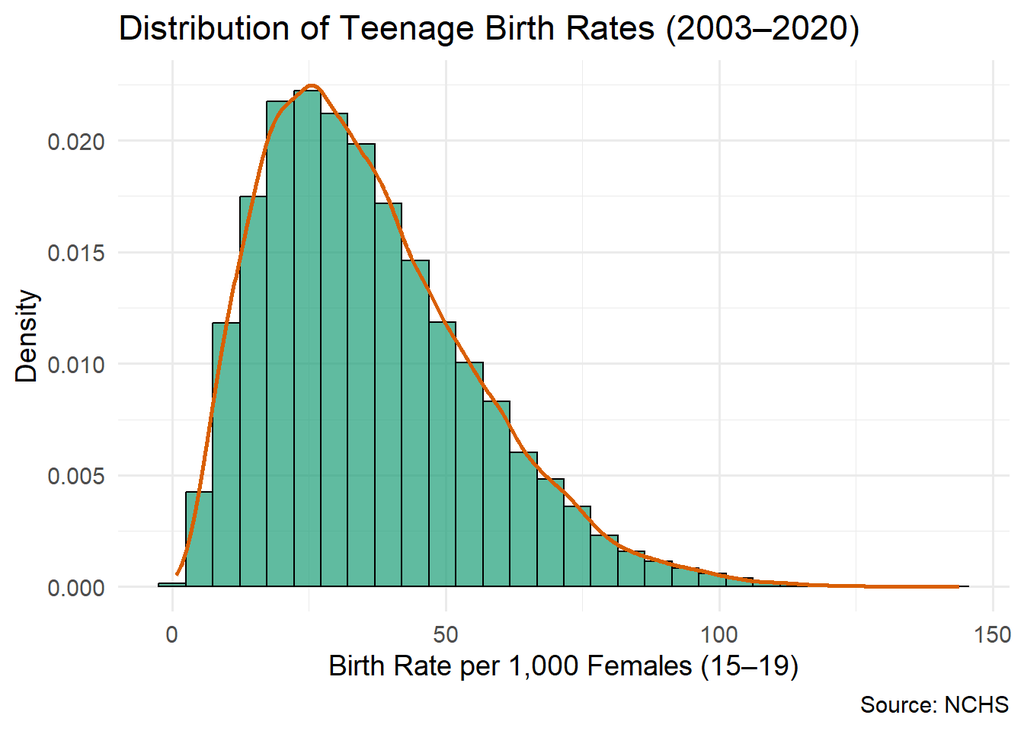

```r
ggplot(df, aes(x = birth_rate)) +
  geom_histogram(aes(y = after_stat(density)), bins = 30, fill = "#1b9e77", color = "black", alpha = 0.7) +
  geom_density(color = "#d95f02", size = 1) +
  labs(title = "Distribution of Teenage Birth Rates (2003–2020)",
       x = "Birth Rate per 1,000 Females (15–19)",
       y = "Density",
       caption = "Source: NCHS") +
  theme_minimal(base_size = 14)
```

The histogram and density plot illustrate the distribution of **teenage birth rates (per 1,000 females aged 15–19) across U.S. counties from 2003 to 2020**. The distribution is **right-skewed**, indicating that while most counties have relatively low to moderate birth rates, a few counties experience significantly higher rates. The peak occurs around **20–40 births per 1,000 females**, with a gradual decline as birth rates increase. The long right tail suggests the presence of extreme values, highlighting disparities across different regions. The density curve provides a smoothed estimate of the probability distribution, reinforcing the skewness and emphasizing the variation in birth rates across counties. This insight is crucial for identifying high-risk areas and targeting interventions effectively.

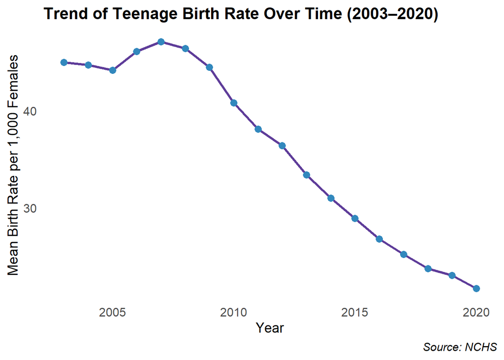

```r
df %>%
  group_by(year) %>%
  summarise(mean_birth_rate = mean(birth_rate, na.rm = TRUE)) %>%
  ggplot(aes(x = year, y = mean_birth_rate)) +
  geom_line(size = 1.2, color = "#5e3c99") +  # deep violet line
  geom_point(size = 3, color = "#3288bd") +  # light blue points
  labs(title = "Trend of Teenage Birth Rate Over Time (2003–2020)",
       x = "Year",
       y = "Mean Birth Rate per 1,000 Females",
       caption = "Source: NCHS") +
  theme_minimal(base_size = 14) +
  theme(
    panel.grid = element_blank(),         # removes all grid lines
    plot.title = element_text(face = "bold", size = 16),
    axis.title = element_text(size = 14),
    axis.text = element_text(size = 12),
    plot.caption = element_text(hjust = 1, face = "italic")
  )
```

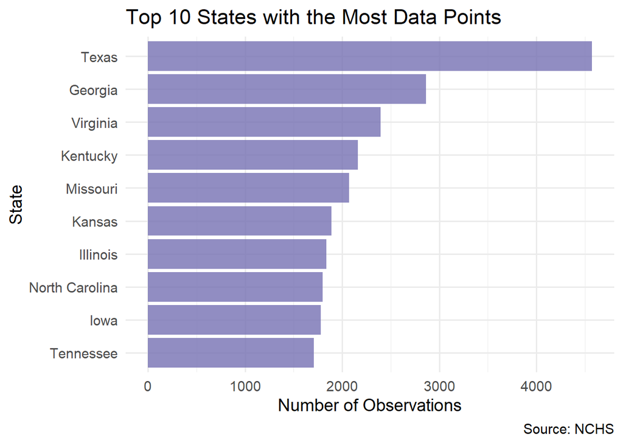

```r
# Top 10 States with the Most Data Points
df %>%
  count(state, sort = TRUE) %>%
  top_n(10, n) %>%
  ggplot(aes(x = reorder(state, n), y = n)) +
  geom_bar(stat = "identity", fill = "#7570b3", alpha = 0.8) +
  coord_flip() +
  labs(title = "Top 10 States with the Most Data Points",
       x = "State",
       y = "Number of Observations",
       caption = "Source: NCHS") +
  theme_minimal(base_size = 14)
```

This bar chart displays the top 10 states with the highest number of observations in the dataset, indicating where the most county-level teenage birth rate data was recorded between 2003 and 2020. Texas leads with the most data points, followed by Georgia, Virginia, and Kentucky, suggesting that these states have more counties or more complete data collection over time. The variation in data availability can influence analysis results and should be considered when interpreting state-level trends.

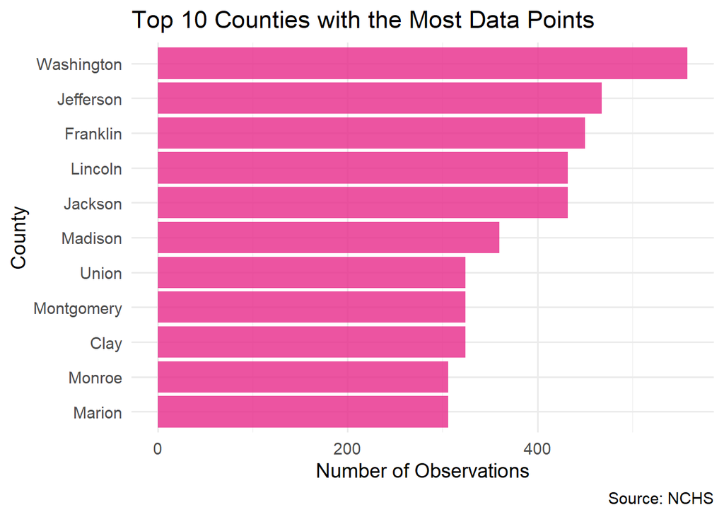

```r
# Top 10 Counties with the Most Data Points
df %>%
  count(county, sort = TRUE) %>%
  top_n(10, n) %>%
  ggplot(aes(x = reorder(county, n), y = n)) +
  geom_bar(stat = "identity", fill = "#e7298a", alpha = 0.8) +
  coord_flip() +
  labs(title = "Top 10 Counties with the Most Data Points",
       x = "County",
       y = "Number of Observations",
       caption = "Source: NCHS") +
  theme_minimal(base_size = 14)
```

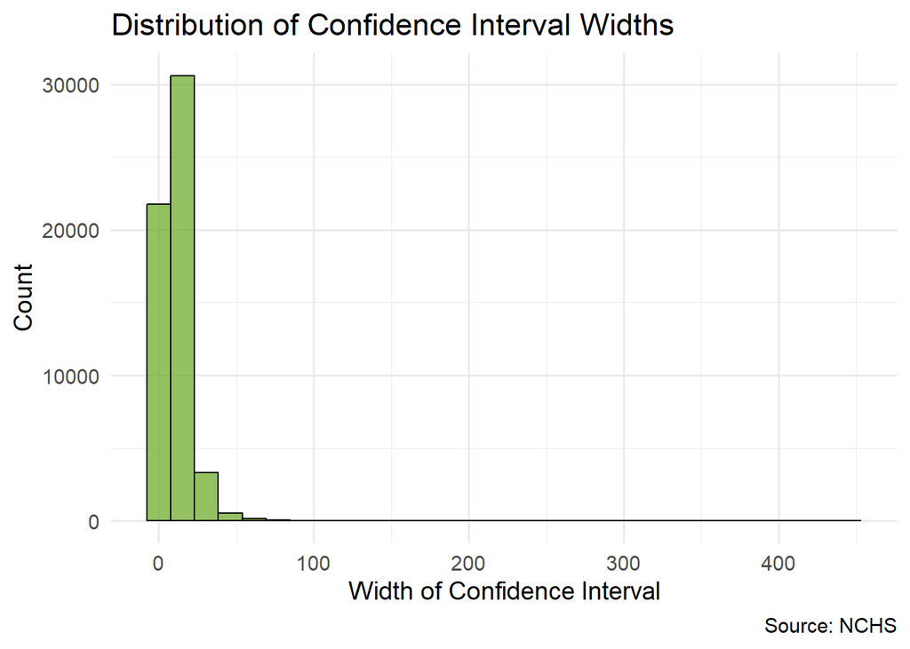

```r
# Compute Confidence Interval Width
df <- df %>%
  mutate(ci_width = upper_confidence_limit - lower_confidence_limit)

# Distribution of Confidence Interval Widths
ggplot(df, aes(x = ci_width)) +
  geom_histogram(bins = 30, fill = "#66a61e", color = "black", alpha = 0.7) +
  labs(title = "Distribution of Confidence Interval Widths",
       x = "Width of Confidence Interval",
       y = "Count",
       caption = "Source: NCHS") +
  theme_minimal(base_size = 14)
```

This histogram illustrates the distribution of confidence interval (CI) widths in teenage birth rate estimates. The majority of observations have relatively small confidence intervals, indicating more precise estimates.

```r
# Select numeric variables for correlation analysis
numeric_vars <- df %>% select(year, birth_rate, lower_confidence_limit, upper_confidence_limit)

# Compute correlation matrix
cor_matrix <- cor(numeric_vars, use = "complete.obs")

# Print correlation matrix
print(cor_matrix)
```

```
##                              year birth_rate lower_confidence_limit
## year                    1.0000000 -0.4420527             -0.4365776
## birth_rate             -0.4420527  1.0000000              0.9838261
## lower_confidence_limit -0.4365776  0.9838261              1.0000000
## upper_confidence_limit -0.4258337  0.9652088              0.9053067
##                        upper_confidence_limit
## year                               -0.4258337
## birth_rate                          0.9652088
## lower_confidence_limit              0.9053067
## upper_confidence_limit              1.0000000
```

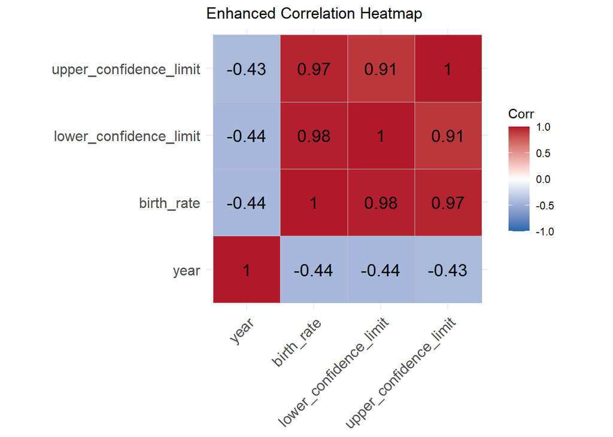

```r
# Generate an improved correlation heatmap
ggcorrplot(cor_matrix,
           method = "square",       # Use squares instead of circles for better visibility
           type = "full",           # Show full matrix for clarity
           lab = TRUE,              # Display correlation coefficients
           lab_size = 5,            # Increase text size
           colors = c("#2166ac", "white", "#b2182b"), # Better contrast (blue to red)
           title = "Enhanced Correlation Heatmap",
           ggtheme = theme_minimal()) +
  theme(axis.text.x = element_text(angle = 45, hjust = 1)) # Rotate x-axis labels for readability
```

The **correlation heatmap** provides insights into the relationships between key numerical variables, including **year, birth rate, lower confidence limit, and upper confidence limit**. A notable observation is the **strong positive correlation between birth rate and its confidence limits**, with a **correlation of 0.98 and 0.97** for the lower and upper bounds, respectively. This suggests that as the estimated teenage birth rate increases, the confidence intervals also expand, indicating higher variability in counties with elevated birth rates. Additionally, the **negative correlation between year and birth rate (-0.44)** confirms the declining trend in teenage birth rates over time, aligning with previous findings. Similarly, year exhibits **a moderate negative correlation with confidence limits (-0.44, -0.43)**, implying that uncertainty in birth rate estimates has also reduced over the years, likely due to improved data collection and reporting practices. Furthermore, the **high correlation (0.91) between lower and upper confidence limits** suggests that counties with wider confidence intervals tend to exhibit consistently large uncertainty ranges in their birth rate estimates. These findings highlight the importance of tracking long-term trends in teenage pregnancy rates and considering confidence intervals when assessing data reliability. Understanding these correlations allows for better interpretation of regional disparities and informs targeted public health interventions aimed at further reducing teenage birth rates.

```r
# Compute state-wise mean birth rate per year
state_trend <- df %>%
  group_by(state, year) %>%
  summarise(mean_birth_rate = mean(birth_rate, na.rm = TRUE))
```

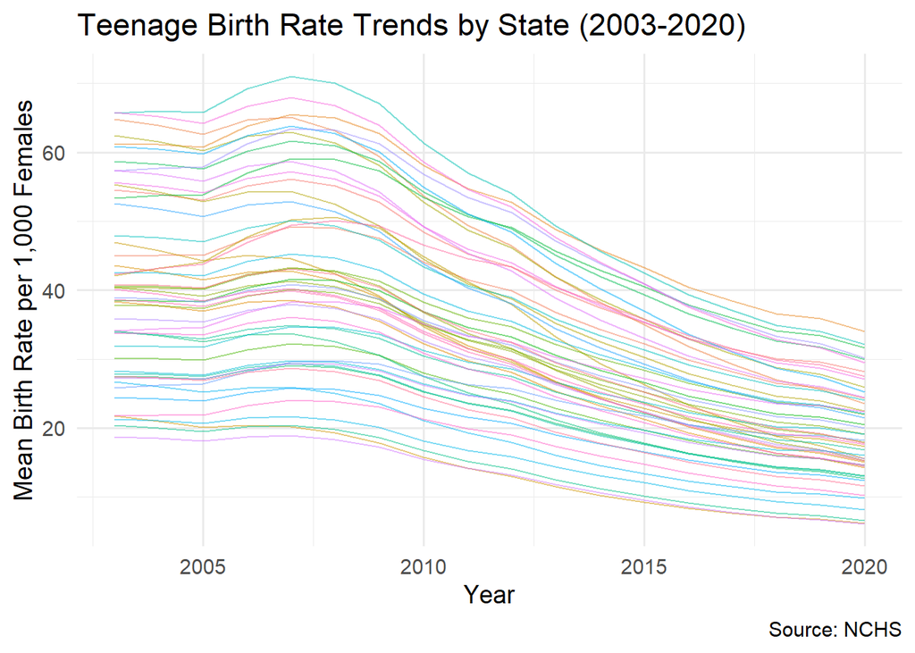

```r
# Plot state-wise trends
ggplot(state_trend, aes(x = year, y = mean_birth_rate, group = state, color = state)) +
  geom_line(alpha = 0.5) +
  labs(title = "Teenage Birth Rate Trends by State (2003-2020)",
       x = "Year",
       y = "Mean Birth Rate per 1,000 Females",
       caption = "Source: NCHS") +
  theme_minimal(base_size = 14) +
  theme(legend.position = "none") # Hide legend to avoid clutter
```

This line graph visualizes the trend of mean teenage birth rates (ages 15–19) across all 51 U.S. states from 2003 to 2020. While states exhibit different initial rates and trajectories, the collective pattern reveals a consistent and substantial decline nationwide. High-rate states like Mississippi and Arkansas started with significantly elevated levels, but even they show downward movement. The convergence of lines in later years suggests a narrowing gap between states, indicating widespread improvement in reducing teenage pregnancies.

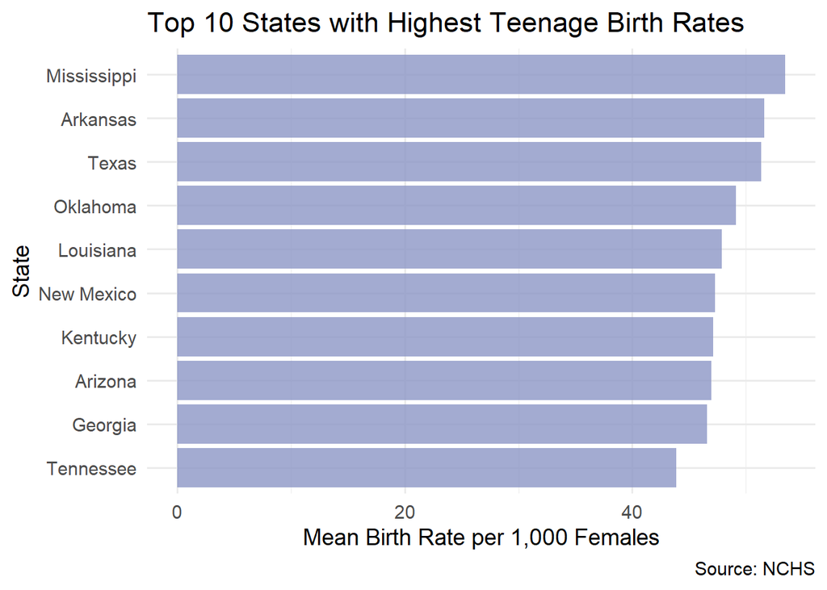

```r
# Compute average birth rate by state
state_avg_birth_rate <- df %>%
  group_by(state) %>%
  summarise(mean_birth_rate = mean(birth_rate, na.rm = TRUE)) %>%
  arrange(desc(mean_birth_rate))

# Plot top 10 states
ggplot(state_avg_birth_rate %>% top_n(10, mean_birth_rate),
       aes(x = reorder(state, mean_birth_rate), y = mean_birth_rate)) +
  geom_bar(stat = "identity", fill = "#8c96c6", alpha = 0.8) +
  coord_flip() +
  labs(title = "Top 10 States with Highest Teenage Birth Rates",
       x = "State",
       y = "Mean Birth Rate per 1,000 Females",
       caption = "Source: NCHS") +
  theme_minimal(base_size = 14)
```

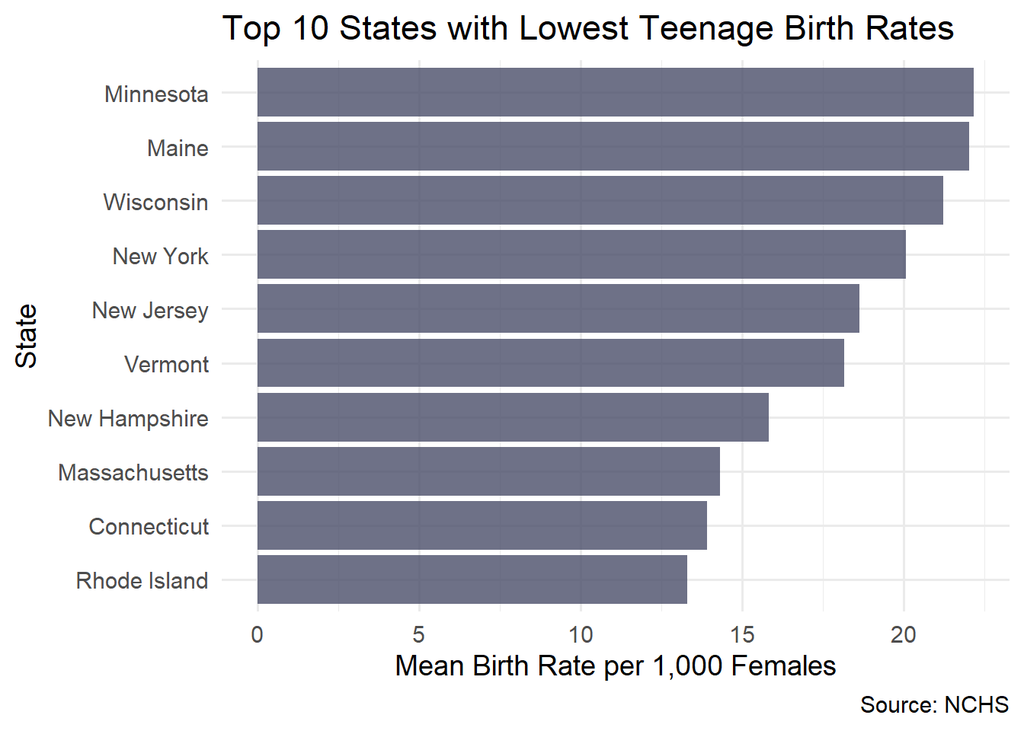

```r
# Plot bottom 10 states
ggplot(state_avg_birth_rate %>% top_n(-10, mean_birth_rate),
       aes(x = reorder(state, mean_birth_rate), y = mean_birth_rate)) +
  geom_bar(stat = "identity", fill =  "#4a4e69", alpha = 0.8) +
  coord_flip() +
  labs(title = "Top 10 States with Lowest Teenage Birth Rates",
       x = "State",
       y = "Mean Birth Rate per 1,000 Females",
       caption = "Source: NCHS") +
  theme_minimal(base_size = 14)
```

In contrast, this chart showcases states with the lowest average teen birth rates across the same period. Northeastern and Upper Midwestern states such as Minnesota, Maine, Wisconsin, and New York demonstrate consistently low rates, with some states maintaining averages below 20 births per 1,000. This pattern reflects potential impacts of enhanced access to healthcare, education, and youth-focused reproductive programs that are often stronger in these regions.

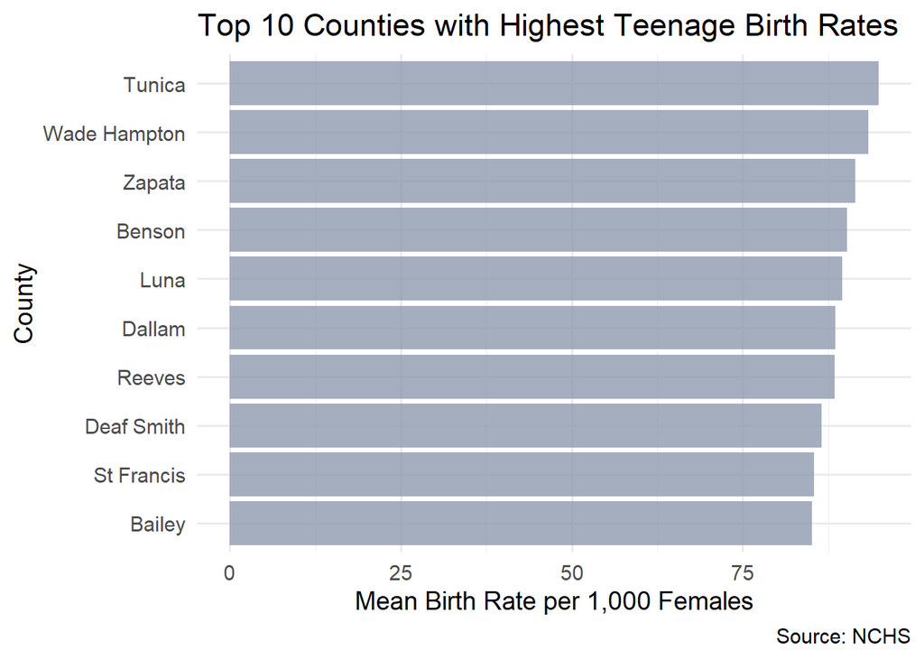

```r
# Compute average birth rate by county
county_avg_birth_rate <- df %>%
  group_by(county) %>%
  summarise(mean_birth_rate = mean(birth_rate, na.rm = TRUE)) %>%
  arrange(desc(mean_birth_rate))

# Plot top 10 counties
ggplot(county_avg_birth_rate %>% top_n(10, mean_birth_rate),
       aes(x = reorder(county, mean_birth_rate), y = mean_birth_rate)) +
  geom_bar(stat = "identity", fill = "#8e9aaf", alpha = 0.8) +
  coord_flip() +
  labs(title = "Top 10 Counties with Highest Teenage Birth Rates",
       x = "County",
       y = "Mean Birth Rate per 1,000 Females",
       caption = "Source: NCHS") +
  theme_minimal(base_size = 14)
```

At the county level, this plot surfaces the top 10 counties with the highest mean birth rates among teens. These counties, including Tunica (MS), Wade Hampton (AK), and Zapata (TX), display birth rates nearing or exceeding 90 births per 1,000 females, more than double the national average. The visualization exposes localized public health challenges, suggesting the need for targeted intervention and localized policy response in these high-burden communities.

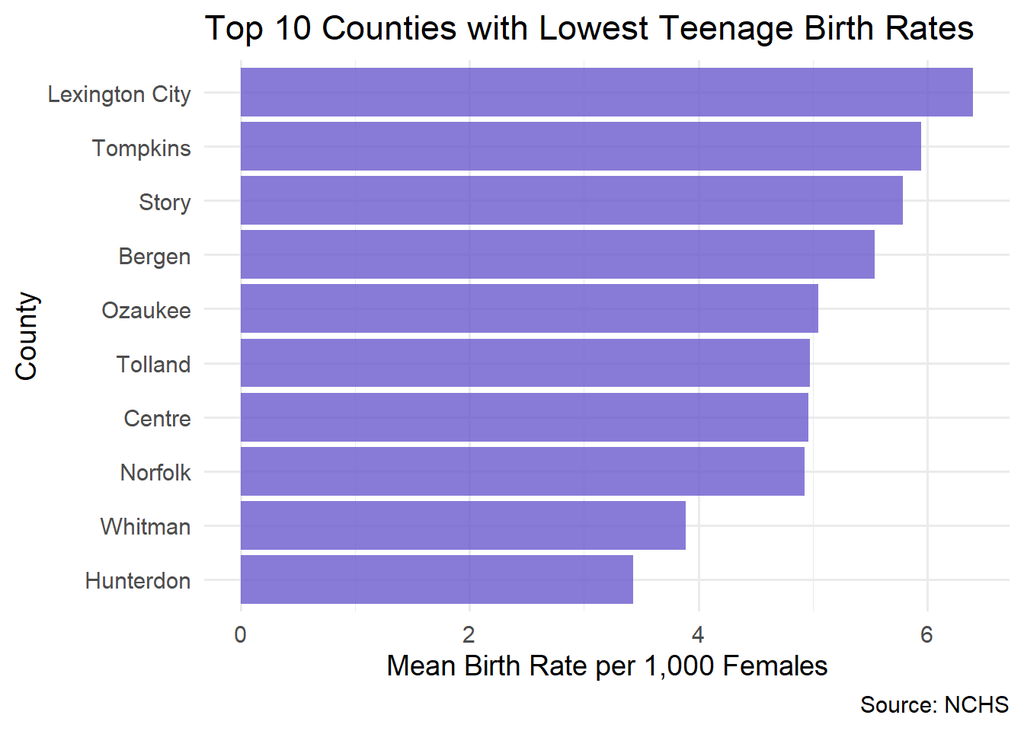

```r
# Plot bottom 10 counties
ggplot(county_avg_birth_rate %>% top_n(-10, mean_birth_rate),
       aes(x = reorder(county, mean_birth_rate), y = mean_birth_rate)) +
  geom_bar(stat = "identity", fill = "#6A5ACD", alpha = 0.8) +
  coord_flip() +
  labs(title = "Top 10 Counties with Lowest Teenage Birth Rates",
       x = "County",
       y = "Mean Birth Rate per 1,000 Females",
       caption = "Source: NCHS") +
  theme_minimal(base_size = 14)
```

This chart presents counties with the lowest mean teen birth rates across the dataset. Counties such as Lexington City (VA), Tompkins (NY), and Story (IA) report extremely low averages — often under 6 births per 1,000. These counties exemplify successful public health environments, possibly characterized by comprehensive sex education, accessible reproductive health services, and strong youth development programs.

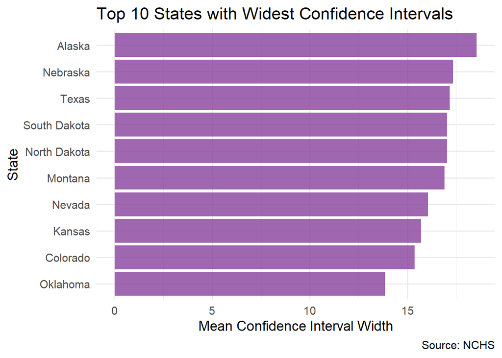

```r
# Compute average confidence interval width per state
ci_width_analysis <- df %>%
  mutate(ci_width = upper_confidence_limit - lower_confidence_limit) %>%
  group_by(state) %>%
  summarise(mean_ci_width = mean(ci_width, na.rm = TRUE)) %>%
  arrange(desc(mean_ci_width))

# Plot states with the widest confidence intervals
ggplot(ci_width_analysis %>% top_n(10, mean_ci_width),
       aes(x = reorder(state, mean_ci_width), y = mean_ci_width)) +
  geom_bar(stat = "identity", fill = "#88419d", alpha = 0.8) +
  coord_flip() +
  labs(title = "Top 10 States with Widest Confidence Intervals",
       x = "State",
       y = "Mean Confidence Interval Width",
       caption = "Source: NCHS") +
  theme_minimal(base_size = 14)
```

This graph identifies states where the uncertainty around the estimated birth rates is greatest, using the width of Bayesian credible intervals. Alaska, Nebraska, and Texas appear at the top, indicating more variability and lower precision in county-level estimates, likely due to sparse populations or data quality issues. This finding emphasizes the importance of considering confidence alongside point estimates when interpreting public health metrics.

```r
# Fetch latest U.S. county shapefile
us_counties <- counties(cb = TRUE, year = 2020, class = "sf")

# Check the structure of the shapefile
head(us_counties)
```

```
## Simple feature collection with 6 features and 12 fields
## Geometry type: MULTIPOLYGON
## Dimension:     XY
## Bounding box:  xmin: -84.94434 ymin: 31.55815 xmax: -81.12884 ymax: 34.98833
## Geodetic CRS:  NAD83
##   STATEFP COUNTYFP COUNTYNS       AFFGEOID GEOID       NAME          NAMELSAD
## 1      13      031 00350302 0500000US13031 13031    Bulloch    Bulloch County
## 2      13      121 01694833 0500000US13121 13121     Fulton     Fulton County
## 3      13      179 00357095 0500000US13179 13179    Liberty    Liberty County
## 4      13      189 00348794 0500000US13189 13189   McDuffie   McDuffie County
## 5      13      213 01688005 0500000US13213 13213     Murray     Murray County
## 6      13      209 00352276 0500000US13209 13209 Montgomery Montgomery County
##   STUSPS STATE_NAME LSAD      ALAND    AWATER                       geometry
## 1     GA    Georgia   06 1750735216  32827779 MULTIPOLYGON (((-82.02684 3...
## 2     GA    Georgia   06 1364133162  19666288 MULTIPOLYGON (((-84.84931 3...
## 3     GA    Georgia   06 1337654102 222884791 MULTIPOLYGON (((-81.8244 32...
## 4     GA    Georgia   06  666590014  23114032 MULTIPOLYGON (((-82.64852 3...
## 5     GA    Georgia   06  892235145   5719644 MULTIPOLYGON (((-84.94433 3...
## 6     GA    Georgia   06  624563058   9191488 MULTIPOLYGON (((-82.65581 3...
```

```r
# Ensure FIPS codes are characters and match formats
df$combined_fips_code <- as.character(df$combined_fips_code)
us_counties$GEOID <- as.character(us_counties$GEOID)

# Merge the shapefile with our dataset
county_data <- us_counties %>%
  left_join(df, by = c("GEOID" = "combined_fips_code"))
```

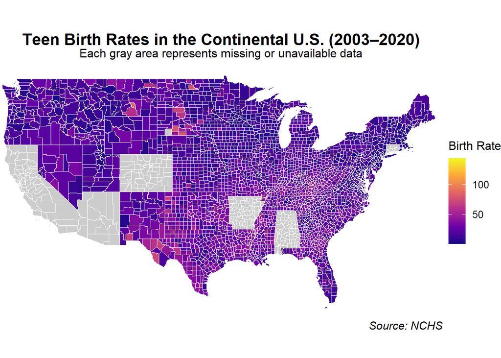

```r
ggplot(county_data) +
  geom_sf(aes(fill = birth_rate), color = "white", size = 0.05) +
  scale_fill_viridis_c(option = "plasma", name = "Birth Rate", na.value = "gray80") +  # Violet scheme + NA in gray
  labs(
    title = "Teen Birth Rates in the Continental U.S. (2003–2020)",
    subtitle = "Each gray area represents missing or unavailable data",
    caption = "Source: NCHS"
  ) +
  coord_sf(xlim = c(-125, -66), ylim = c(24, 50), expand = FALSE) +
  theme_void(base_size = 14) +  # Removes axes and grid
  theme(
    plot.title = element_text(face = "bold", size = 16, hjust = 0.5),
    plot.subtitle = element_text(size = 12, hjust = 0.5, margin = margin(b = 10)),
    plot.caption = element_text(hjust = 1, face = "italic"),
    legend.title = element_text(size = 12),
    legend.text = element_text(size = 10)
  )
```

[figure not shown]

```r
ggplot(county_data %>% filter(year %in% c(2003, 2010, 2020))) +
  geom_sf(aes(fill = birth_rate), color = "white", size = 0.05) +
  scale_fill_viridis_c(option = "plasma", name = "Birth Rate") +
  facet_wrap(~year, nrow = 1) +
  labs(
    title = "Teen Birth Rates Across U.S. Counties (2003, 2010, 2020)",
    caption = "Source: NCHS"
  ) +
  theme_minimal(base_size = 16) +
  theme_void(base_size = 30) +  # Removes axes and grid
  theme(strip.text = element_text(size = 18))
```

These faceted choropleth maps provide a temporal snapshot of how teen birth rates have evolved spatially over time. In 2003, a broader spread of high-rate counties is evident. By 2010, a slight improvement is visible, and by 2020, a significant reduction in high-rate counties is apparent. This layout compellingly demonstrates both the temporal progress made and the counties where high rates persist, helping to guide further investigation and action.